# Neuroevolution and Direct Policy Search

## Continuous State, Continuous Action

- Approximating \(Q(s, a)\) does not help, we cannot (simply) determine \(\arg\max_a Q(s, a)\) to infer a policy.
- We can discretize \(A\).
- Instead, we can approximate \(\pi_{\boldsymbol{w}}(s) = a\) directly (direct policy search).

## Parametrizable Policy

- Neuroevolution: Artificial neural network (ANN) which maps states to actions
- Weight vector \(\boldsymbol{w}\) can be modified

## Optimizer

- Gradient-free optimizer (because we cannot determine the *correct* action)
- Usually either
  - evolutionary algorithms (e.g. CMA-ES, CoSyNE, ...) or
  - RL algorithms (e.g. RWR, PoWER, \(PI^2\), REPS, ...)
- Adjusts \(\boldsymbol{w}\) to maximize the return (sum of rewards)

[figure not shown]

Neuroevolution

# CMA-ES

- **C**ovariance **M**atrix **A**daptation **E**volution **S**trategy
- Derivative-free optimization algorithm, mimimizes fitness functions that are
  - non-linear
  - non-separable
  - noisy
  - ill-conditioned
- Should not be used
  - for a very small number of parameters
  - for a very large number of parameters (requires inversion of a covariance matrix)
  - if exact derivatives are available
- See [Nikolaus Hansens's webpage](https://www.lri.fr/~hansen/cmaesintro.html) or [Wikipedia](http://en.wikipedia.org/wiki/CMA-ES) for more details.

```python
%pylab inline
```

```python
def objective(x):
    return sqrt(x[0]**2+x[1]**2)
```

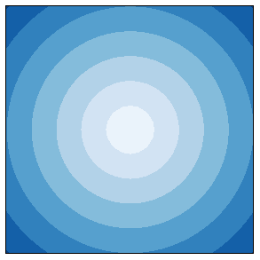

```python
def plot_objective():
    x, y = meshgrid(arange(-1.6, 1.6, 0.1), arange(-1.6, 1.6, 0.1))
    z = [[objective([x[i,j], y[i,j]]) for i in range(x.shape[0])] for j in range(x.shape[1])]
    contourf(x, y, z, cmap=cm.Blues)
    setp(gca(), xticks=(), yticks=(), xlim=(-1.5, 1.5), ylim=(-1.5, 1.5))

figure(figsize=(5, 5))
plot_objective()
```

```python
def equiprobable_ellipse(C, factor=1.0):
    """Source: http://stackoverflow.com/questions/12301071/multidimensional-confidence-intervals"""
    def eigsorted(C):
        vals, vecs = linalg.eigh(C)
        order = vals.argsort()[::-1]
        return vals[order], vecs[:,order]
    vals, vecs = eigsorted(C)
    angle = arctan2(*vecs[:,0][::-1])
    width, height = 2 * factor * np.sqrt(vals)
    return angle, width, height

def plot_ellipse(C, mean=zeros(2)):
    from matplotlib.patches import Ellipse
    angle, width, height = equiprobable_ellipse(C)
    e = Ellipse(xy=mean, width=width, height=height,
                angle=degrees(angle), ec="orange",
                fc="none", lw=3, ls="dashed")
    gca().add_artist(e)
```

```python
__import__("sys").path.append("05_neuroevolution")
from barecmaes2 import Cmaes
opt = Cmaes(xstart=[1.0, 1.0], sigma=0.1, ftarget=1e-10, popsize=50)
```

```python
def plot_generations(n_generations):
    figure(figsize=(n_generations*4, 4))
    for it in range(n_generations):
        X = asarray(opt.ask())
        F = [objective(x) for x in X]
        subplot(1, n_generations, it+1)
        plot_objective()
        plot_ellipse(C=opt.sigma*asarray(opt.C), mean=opt.xmean)
        weights = zeros_like(F)
        weights[argsort(F)[:len(opt.weights)]] = opt.weights
        scatter(X[:, 0], X[:, 1], c=weights, cmap=cm.gray)
        opt.tell(X, F)
```

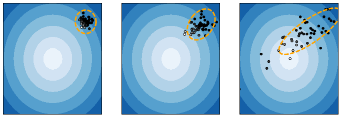

```python
plot_generations(n_generations=3)
```

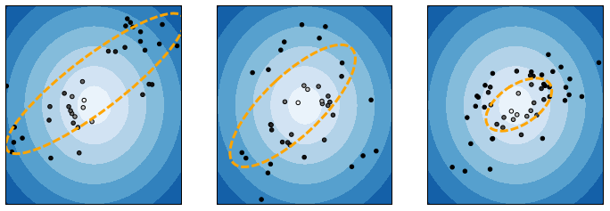

```python
plot_generations(n_generations=3)
```

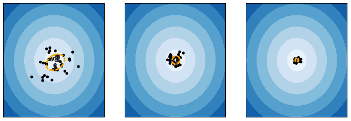

```python
plot_generations(n_generations=3)
```

## Double Pole Balancing

```python
from IPython.display import YouTubeVideo
YouTubeVideo("5y3UTEgFH2Q")
```

[video not shown]

## Octopus Arm

```python
YouTubeVideo("AxeeHif0euY")
```

[video not shown]

## TORCS

```python
YouTubeVideo("3JiNC6vw8zE")
```

[video not shown]

This problem also has been solved with **visual** input.

# Partially Observable Markov Decision Processes (POMDP)

Markov property:

\[P(s_{t+1}|a_t,s_t,\ldots,a_0,s_0) = P(s_{t+1}|a_t,s_t)\]

But we cannot observe \(s_t\) completely!

## Question 1

Can you give examples for partially observable Markov decision processes?

## Question 2

How can we deal with partial observability?

## Answer 2

- State estimation
  - Bayes filters (e.g. particle filter, Kalman filter)
  - Exponential smoothing
  - \(\boldsymbol{\alpha}\)-\(\boldsymbol{\beta}\) **filter**
  - ...
- Use recurrent connections
- We need some kind of **memory**

## Smoothing Noisy Observations with \(\alpha\)-\(\beta\) Filters

```python
class ABF(object):
    """Alpha-beta filter."""
    def __init__(self, g, delta):
        r = (4+g-sqrt(8*g+g**2))/4
        self.a, self.b = 1-r**2, 2*(1-r)**2
        self.delta = delta
        self.s, self.sd = None, None
    def step(self, s):
        if self.s == None: self.s, self.sd = s, zeros_like(s)
        se = self.s + self.delta * self.sd
        sde = self.sd
        r = s - se
        self.s = se + self.a * r
        self.sd = sde + self.b/self.delta * r
        return self.s, self.sd
```

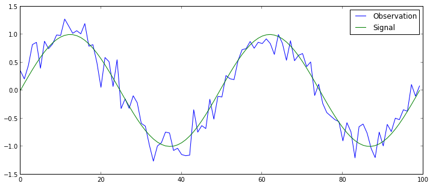

```python
random.seed(0)

steps = 100
X = linspace(0, numpy.pi*4, steps)
S = sin(X)
Sn = S + random.randn(*S.shape)*0.2

figure(figsize=(12, 5))
plot(Sn, label="Observation")
plot(S, label="Signal")
r = legend()
```

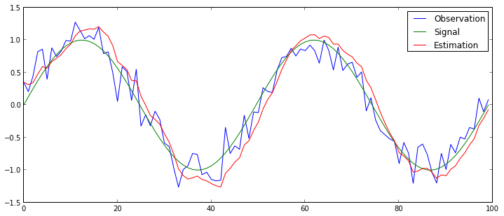

```python
abf = ABF(g=0.05, delta=1.0)

SE = []
SDE = []
for s in range(steps):
    se, sd = abf.step(Sn[s])
    SE.append(se)
    SDE.append(sd)

figure(figsize=(12, 5))
plot(Sn, label="Observation")
plot(S, label="Signal")
plot(SE, label="Estimation")
r = legend()
```

# Policy Search in Robotics

- Often we use a policy of the form \(\pi(s_t) = s_{t+1}\), that maps from a state to its successor.
- \(\pi\) generates a **trajectory**.
- We can use low-level controllers to generate an action that transfers from \(s_t\) to \(s_{t+1}\).
- We can even work in **task space** (e.g. Cartesian end-effector coordinates):
  - We need inverse kinematics (IK) to determine joint angles
  - We could use inverse dynamics to determine torques

## Policy Representations in Robotics

General function approximators

- Gaussian mixture models
- Gaussian process regression
- Radial basis functions
- Neural networks

Nonlinear dynamical systems

- Stable estimators of dynamical systems (SEDS)
- Dynamical movement primitives (DMP)
- Parametric dynamical movement primitives (PDMP)

Via points and splines

- Probabilistic movement primitives (ProMP)
- Bézier splines (B-splines)
- ...

## Applications in Robotics

- [Table tennis](http://www.youtube.com/watch?v=cPIGGKBnUZI)
- [Pancake flipping](http://www.youtube.com/watch?v=W_gxLKSsSIE)
- Ball throwing
- Darts